# Exploring genome size in different organisms

## Shishi Luo

To practice some basic Tables operations, we'll play with data from the NIH NCBI database that contains the genome size, number of genes, number of proteins, etc, for tens of thousands of organisms

```python
# you kids can ignore this housekeeping code for now
from datascience import *
%matplotlib inline
import matplotlib.pyplot as plt
import numpy as np
plt.style.use('fivethirtyeight')
```

# Data source

http://www.ncbi.nlm.nih.gov/genome/browse/ has an extensive list of genome information by organism.

You can download the information about whatever organisms you're interested in. Here's an example of the data I've downloaded for some model organisms.

```python
model_species=Table.read_table(
    'https://raw.githubusercontent.com/shishiluo/Genomics-DataScience/master/data/model_species.csv')
```

```python
model_species
```

| Scientific name | Common name | Genes | Proteins | Size |
| --- | --- | --- | --- | --- |
| Escherichia coli | E. coli | 5618 | 5358 | 5478680 |
| Arabidopsis thaliana | A. thaliana | 33583 | 35378 | 119668000 |
| Caenorhabditis elegans | C. elegans | 46711 | 27943 | 100286000 |
| Danio rerio | Zebrafish | 39803 | 47861 | 1371720000 |
| Drosophila melanogaster | Fruit fly | 17651 | 30443 | 143726000 |
| Gallus gallus | Chicken | 25062 | 46393 | 1230260000 |
| Mus musculus | Mouse | 48855 | 78065 | 2803570000 |
| Saccharomyces cerevisiae S288c | Yeast | 6350 | 5907 | 12157100 |
| Rattus norvegicus | Rat | 37647 | 50706 | 2870180000 |
| Zea mays | Corn (maize) | 104305 | 116015 | 2067620000 |
| Oryza sativa Japonica Group | Rice | 66100 | 81951 | 374423000 |
| Canis lupus familiaris | Dog | 30186 | 47089 | 2410980000 |
| Influenza A virus (A/New York/392/2004(H3N2)) | Influenza | 12 | 12 | 13627 |
| Human immunodeficiency virus 1 | HIV | 10 | 10 | 9181 |
| Ailuropoda melanoleuca | Giant panda | 27613 | 32507 | 2299510000 |

By default, only the first ten rows will be displayed. If you'd like to see all the rows (after all, there are only 5 that are omitted), replace `model_species` with `model_species.show()` above.

# Exploration

Let's mess around with the data in this table. What is the distribution of genome size?

```python
model_species.sort('Size').show()
```

| Scientific name | Common name | GC% | Genes | Proteins | Size |
| --- | --- | --- | --- | --- | --- |
| Human immunodeficiency virus 1 | HIV | 42.1 | 10 | 10 | 9181 |
| Influenza A virus (A/New York/392/2004(H3N2)) | Influenza | 42.9178 | 12 | 12 | 13627 |
| Escherichia coli | E. coli | 50.5 | 5618 | 5358 | 5478680 |
| Saccharomyces cerevisiae S288c | Yeast | 38.1556 | 6350 | 5907 | 12157100 |
| Caenorhabditis elegans | C. elegans | 35.4317 | 46711 | 27943 | 100286000 |
| Arabidopsis thaliana | A. thaliana | 36.0528 | 33583 | 35378 | 119668000 |
| Drosophila melanogaster | Fruit fly | 42.0803 | 17651 | 30443 | 143726000 |
| Oryza sativa Japonica Group | Rice | 43.5758 | 66100 | 81951 | 374423000 |
| Gallus gallus | Chicken | 42.9197 | 25062 | 46393 | 1230260000 |
| Danio rerio | Zebrafish | 36.6591 | 39803 | 47861 | 1371720000 |
| Zea mays | Corn (maize) | 46.8286 | 104305 | 116015 | 2067620000 |
| Ailuropoda melanoleuca | Giant panda | 41.7 | 27613 | 32507 | 2299510000 |
| Canis lupus familiaris | Dog | 41.3022 | 30186 | 47089 | 2410980000 |
| Mus musculus | Mouse | 41.9419 | 48855 | 78065 | 2803570000 |
| Rattus norvegicus | Rat | 42.3282 | 37647 | 50706 | 2870180000 |

That's about $10^4$ bases for the shortest genome and nearly $3\times10^9$ bases for the longest genome!  
For reference, the human genome is $3.2\times 10^9$, or 3.2 billion bases.

Does the ordering by size of genome jibe with your preconceptions about the organisms?

Let's look at the number of genes.

```python
model_species.sort('Genes').show()
```

| Scientific name | Common name | Genes | Proteins | Size |
| --- | --- | --- | --- | --- |
| Human immunodeficiency virus 1 | HIV | 10 | 10 | 9181 |
| Influenza A virus (A/New York/392/2004(H3N2)) | Influenza | 12 | 12 | 13627 |
| Escherichia coli | E. coli | 5618 | 5358 | 5478680 |
| Saccharomyces cerevisiae S288c | Yeast | 6350 | 5907 | 12157100 |
| Drosophila melanogaster | Fruit fly | 17651 | 30443 | 143726000 |
| Gallus gallus | Chicken | 25062 | 46393 | 1230260000 |
| Ailuropoda melanoleuca | Giant panda | 27613 | 32507 | 2299510000 |
| Canis lupus familiaris | Dog | 30186 | 47089 | 2410980000 |
| Arabidopsis thaliana | A. thaliana | 33583 | 35378 | 119668000 |
| Rattus norvegicus | Rat | 37647 | 50706 | 2870180000 |
| Danio rerio | Zebrafish | 39803 | 47861 | 1371720000 |
| Caenorhabditis elegans | C. elegans | 46711 | 27943 | 100286000 |
| Mus musculus | Mouse | 48855 | 78065 | 2803570000 |
| Oryza sativa Japonica Group | Rice | 66100 | 81951 | 374423000 |
| Zea mays | Corn (maize) | 104305 | 116015 | 2067620000 |

For reference, it is estimated that the human genome contains about 60,000 genes.

```python
model_species.where(model_species['Genes']>60000)
```

| #Organism/Name | GC% | Genes | Proteins | Size |
| --- | --- | --- | --- | --- |
| Zea mays | 46.8286 | 104305 | 116015 | 2,067,620,000.00 |
| Oryza sativa Japonica Group | 43.5758 | 66100 | 81951 | 374,423,000.00 |

Simply counting the size of the genome or the number of genes does not always tell us much about what kind of organism it belongs to.

Finally, recalling the central dogma of molecular biology, let's plot the number of genes in an organism against the number of proteins.

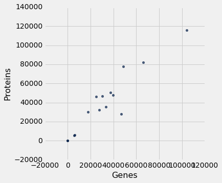

```python
model_species.scatter('Genes', 'Proteins')
```

Does a similar relationship exist between the size of the genome and the number of genes?

# Moving on to bigger things

Let's do some exploratory analysis on a larger dataset, this time on all organisms classified as animals (i.e. all living things except plants, fungi, microorganisms) and for which we have full genome information.

```python
animals=Table.read_table(
    'https://raw.githubusercontent.com/shishiluo/Genomics-DataScience/master/data/animals.csv')
```

```python
animals.show()
```

| Organism/Name | Strain | SubGroup | Size (Mb) | Scaffolds | Genes | Proteins |
| --- | --- | --- | --- | --- | --- | --- |
| Drosophila yakuba | Tai18E2 | Insects | 165.71 | 8123 | 16079 | 23317 |
| Homo sapiens | nan | Mammals | 3231.3 | 801 | 56201 | 102633 |
| Caenorhabditis briggsae | AF16 | Roundworms | 108.384 | 638 | 22736 | 21959 |
| Caenorhabditis elegans | Bristol N2 | Roundworms | 100.286 | 7 | 46711 | 27943 |
| Anopheles gambiae str. PEST | PEST | Insects | 265.027 | 8145 | 13184 | 14099 |
| Drosophila melanogaster | nan | Insects | 143.726 | 1870 | 17651 | 30443 |
| Apis mellifera | DH4 | Insects | 250.287 | 5645 | 13401 | 21777 |
| Danio rerio | Tuebingen | Fishes | 1371.72 | 3399 | 39803 | 47861 |
| Mus musculus | C57BL/6J | Mammals | 2803.57 | 293 | 48855 | 78065 |
| Ciona intestinalis | nan | Other Animals | 115.227 | 1280 | 14983 | 15438 |
| Takifugu rubripes | nan | Fishes | 391.485 | 7091 | 23164 | 31052 |
| Rattus norvegicus | mixed | Mammals | 2870.18 | 1395 | 37647 | 50706 |
| Felis catus | nan | Mammals | 2641.34 | 267928 | 25364 | 33226 |
| Bos taurus | nan | Mammals | 2670.14 | 6337 | 32432 | 49107 |
| Sus scrofa | nan | Mammals | 2808.53 | 9906 | 38792 | 47400 |
| Ornithorhynchus anatinus | nan | Mammals | 1995.61 | 200283 | 23777 | 26109 |
| Gallus gallus | nan | Birds | 1230.26 | 23870 | 25062 | 46393 |
| Meleagris gallopavo | nan | Birds | 1128.34 | 233806 | 20903 | 26423 |
| Coturnix japonica | nan | Birds | 927.657 | 2531 | 20522 | 39088 |
| Equus caballus | nan | Mammals | 2474.93 | 9688 | 26948 | 36064 |
| Oreochromis niloticus | nan | Fishes | 927.696 | 5910 | 30411 | 47714 |
| Papio anubis | nan | Mammals | 2948.4 | 72501 | 38695 | 54082 |
| Ovis aries | nan | Mammals | 2615.52 | 5466 | 57491 | 85433 |
| Canis lupus familiaris | nan | Mammals | 2410.98 | 3310 | 30186 | 47089 |
| Drosophila simulans | w501 | Insects | 124.966 | 7619 | 15229 | 24119 |
| Pan troglodytes | nan | Mammals | 3309.58 | 27005 | 34813 | 56786 |
| Monodelphis domestica | nan | Mammals | 3598.44 | 5223 | 36227 | 45804 |
| Tribolium castaneum | Georgia GA2 | Insects | 210.265 | 2322 | 13181 | 18076 |
| Drosophila pseudoobscura pseudoobscura | MV2-25 | Insects | 152.696 | 4790 | 16721 | 23456 |
| Macaca mulatta | nan | Mammals | 3236.22 | 286263 | 186 | 99 |
| Schistosoma mansoni | Puerto Rico | Flatworms | 364.538 | 885 | 15882 | 11787 |
| Oryctolagus cuniculus | nan | Mammals | 2737.46 | 3318 | 28903 | 37564 |
| Pongo abelii | nan | Mammals | 3441.24 | 79342 | 32434 | 37509 |
| Taeniopygia guttata | nan | Birds | 1232.14 | 37422 | 17357 | 19447 |
| Salmo salar | nan | Fishes | 2966.89 | 241573 | 116 | 13 |
| Callithrix jacchus | nan | Mammals | 2914.96 | 16399 | 34856 | 44212 |
| Nasonia vitripennis | AsymCX | Insects | 295.781 | 6169 | 14273 | 24671 |
| Nomascus leucogenys | nan | Mammals | 2962.06 | 17524 | 28462 | 38654 |
| Oryzias latipes | Hd-rR | Fishes | 869.818 | 7307 | 26074 | 34487 |
| Anolis carolinensis | nan | Reptiles | 1799.14 | 6646 | 21624 | 32243 |
| Macaca fascicularis | nan | Mammals | 2946.84 | 7625 | 33107 | 62703 |
| Gorilla gorilla gorilla | nan | Mammals | 3035.66 | 57197 | 31329 | 33704 |
| Bombus terrestris | nan | Insects | 248.654 | 5678 | 11188 | 20321 |
| Strongyloides ratti | ED321 Heterogonic | Roundworms | 43.1502 | 135 | 12451 | 12450 |
| Lepisosteus oculatus | nan | Fishes | 945.878 | 2106 | 21770 | 41647 |
| Pan paniscus | nan | Mammals | 3286.64 | 10984 | 95 | 15 |
| Capra hircus | nan | Mammals | 2635.85 | 77432 | 26912 | 30164 |
| Microtus ochrogaster | nan | Mammals | 2287.34 | 6450 | 24260 | 30752 |
| Cynoglossus semilaevis | nan | Fishes | 470.199 | 31181 | 24079 | 31632 |
| Ficedula albicollis | nan | Birds | 1118.34 | 21836 | 16778 | 26090 |
| Chrysemys picta bellii | nan | Reptiles | 2365.77 | 78631 | 24356 | 42558 |
| Parus major | nan | Birds | 1020.31 | 1676 | 35872 | 76327 |
| Chlorocebus sabaeus | nan | Mammals | 2789.66 | 2022 | 35027 | 61803 |
| Esox lucius | nan | Fishes | 904.453 | 1709 | 26012 | 43433 |
| Poecilia reticulata | Guanapo | Fishes | 731.622 | 3029 | 26235 | 42641 |
| Bos taurus | nan | Mammals | 2724.98 | 5998 | 32776 | 28999 |
| Rattus norvegicus | BN; Sprague-Dawley | Mammals | 2616.42 | 7271 | 34589 | 26739 |
| Mus musculus | mixed | Mammals | 2775.06 | 13033 | 43359 | 30240 |
| Drosophila simulans | white501 | Insects | 137.843 | 10601 | 16011 | 15428 |
| Macaca mulatta | nan | Mammals | 2969.97 | 38224 | 21524 | 17802 |
| Macaca fascicularis | nan | Mammals | 3126.56 | 45468 | 1792 | 1537 |

Now that we have such a long list, use a histogram to visualize the distribution of genome size.

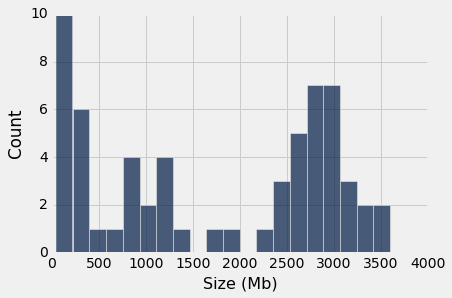

```python
animals.hist('Size (Mb)', bins=20, normed=False)
```

Note the units for genome size are in millions of bases (Mega bases, Mb for short). Why didn't we do this earlier?

Let's use the information in the column 'SubGroup' to see if the sizes break down by sub-group

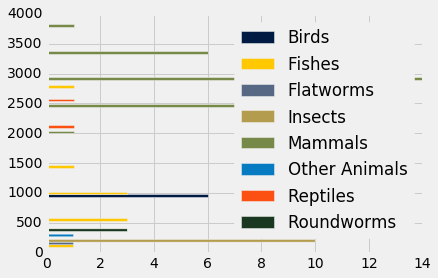

```python
animals.pivot_hist('SubGroup', 'Size (Mb)', bins=np.linspace(1,4000, 10),
                   normed=False, orientation='horizontal')
```

Does the relationship between the number of genes and proteins still seem to hold? What about between genome size and number of genes?

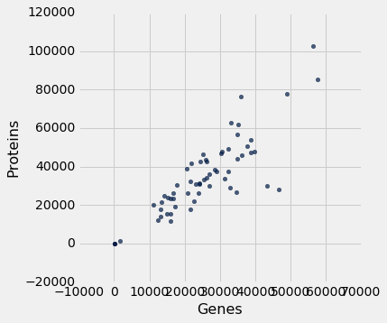

```python
animals.scatter('Genes', 'Proteins')
```

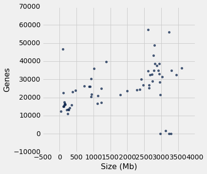

```python
animals.scatter('Size (Mb)', 'Genes')
```

# Explore on your own

Below you'll download a dataset for viruses (that infect humans). For each cell, look at the code and the output and write your own comments on what you think the code is doing. If there's any interesting you observe about the output, feel free to write that in the comments too.

```python
virus=Table.read_table(
    'https://raw.githubusercontent.com/shishiluo/Genomics-DataScience/master/data/virus.csv')

# (I'll do this first one for you) Download the data from the github repository
```

```python
virus
```

| Virus name | Size (Kb) | Host | Genes | Proteins |
| --- | --- | --- | --- | --- |
| Aedes flavivirus | 11.064 | vertebrates, invertebrates, human | 1 | 2 |
| Great Island virus | 17.858 | vertebrates, invertebrates, human | 11 | 11 |
| Candiru virus | 12.495 | vertebrates, invertebrates, human | 4 | 4 |
| Sandfly fever Turkey virus | 12.603 | vertebrates, invertebrates, human | 4 | 4 |
| Rift Valley fever virus | 11.979 | vertebrates, invertebrates, human | 4 | 4 |
| Bunyamwera virus | 12.294 | vertebrates, invertebrates, human | 4 | 4 |
| Eyach virus | 29.21 | vertebrates, invertebrates, human | 13 | 13 |
| La Crosse virus | 12.491 | vertebrates, invertebrates, human | 4 | 4 |
| Dugbe virus | 18.859 | vertebrates, invertebrates, human | 3 | 3 |
| Colorado tick fever virus | 29.174 | vertebrates, invertebrates, human | 13 | 13 |

... (367 rows omitted)

```python
virus.where(virus['Virus name']=='Zika virus')
```

| Virus name | Size (Kb) | Host | Genes | Proteins |
| --- | --- | --- | --- | --- |
| Zika virus | 10.794 | vertebrates, invertebrates, human | 1 | 1 |

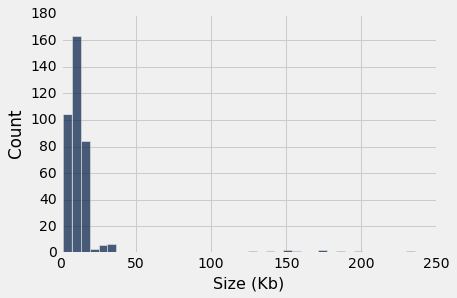

```python
virus.hist('Size (Kb)', bins=40, normed=False)
```

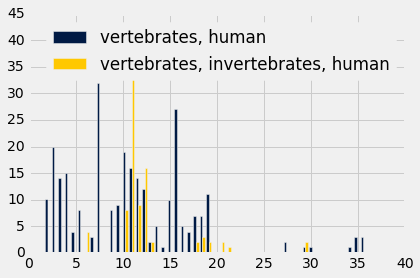

```python
virus.where(virus['Size (Kb)']<100).pivot_hist('Host', 'Size (Kb)', bins=50, normed=False)
```

```python
virus.where(virus['Size (Kb)']==min(virus['Size (Kb)']))
```

| Virus name | Size (Kb) | Host | Genes | Proteins |
| --- | --- | --- | --- | --- |
| Hepatitis delta virus | 1.682 | vertebrates, human | 2 | 2 |

```python
virus.where(virus['Size (Kb)']<3)
```

| Virus name | Size (Kb) | Host | Genes | Proteins |
| --- | --- | --- | --- | --- |
| Torque teno mini virus 8 | 2.91 | vertebrates, human | 2 | 2 |
| Torque teno sus virus 1a | 2.878 | vertebrates, human | 3 | 3 |
| Torque teno canis virus | 2.797 | vertebrates, human | 3 | 3 |
| Torque teno felis virus | 2.064 | vertebrates, human | 3 | 3 |
| Torque teno mini virus 7 | 2.952 | vertebrates, human | 2 | 2 |
| Torque teno mini virus 2 | 2.765 | vertebrates, human | 3 | 3 |
| Torque teno mini virus 3 | 2.897 | vertebrates, human | 3 | 3 |
| Torque teno mini virus 5 | 2.908 | vertebrates, human | 3 | 3 |
| Torque teno mini virus 4 | 2.785 | vertebrates, human | 2 | 2 |
| Torque teno mini virus 6 | 2.897 | vertebrates, human | 3 | 3 |

... (20 rows omitted)

```python
virus.where(virus['Size (Kb)']==max(virus['Size (Kb)']))
```

| Virus name | Size (Kb) | Host | Genes | Proteins |
| --- | --- | --- | --- | --- |
| Human herpesvirus 5 | 235.646 | vertebrates, human | 173 | 169 |

```python
virus.where(virus['Size (Kb)']>100)
```

| Virus name | Size (Kb) | Host | Genes | Proteins |
| --- | --- | --- | --- | --- |
| Human herpesvirus 8 | 137.969 | vertebrates, human | 96 | 86 |
| Human herpesvirus 5 | 235.646 | vertebrates, human | 173 | 169 |
| Human herpesvirus 7 | 153.08 | vertebrates, human | 86 | 86 |
| Variola virus | 185.578 | vertebrates, human | 197 | 197 |
| Human herpesvirus 3 | 124.884 | vertebrates, human | 73 | 73 |
| Human herpesvirus 1 | 152.222 | vertebrates, human | 79 | 77 |
| Vaccinia virus | 194.711 | vertebrates, human | 223 | 223 |
| Human herpesvirus 4 type 2 | 172.764 | vertebrates, human | 82 | 80 |
| Human herpesvirus 2 | 154.675 | vertebrates, human | 79 | 77 |
| Human herpesvirus 4 | 171.823 | vertebrates, human | 152 | 95 |

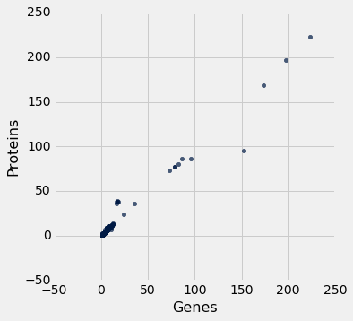

```python
virus.scatter('Genes', 'Proteins')
```

How does the number of proteins per gene in viruses compare to that of in the animals dataset above?

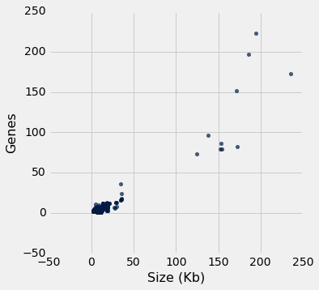

```python
virus.scatter('Size (Kb)','Genes')
```

How does the number of genes per Kb in viruses compare to that of in the animals dataset above?